# Final Analysis: COVID-19 in Mexico

Matt Querdasi and Sophie Cohen

March 22, 2021

## About the Data

The data set contains a sample of individuals hospitalized in Mexico with a suspected severe case of COVID. We will determine what factors relate to time until release from hospital. Below we examine the variables to see which contribute to a patient’s release from the hospital. We chose these variables because some are known covid risk factors, while others that were included in the dataset just seemed interesting to analyze (such as nationality).

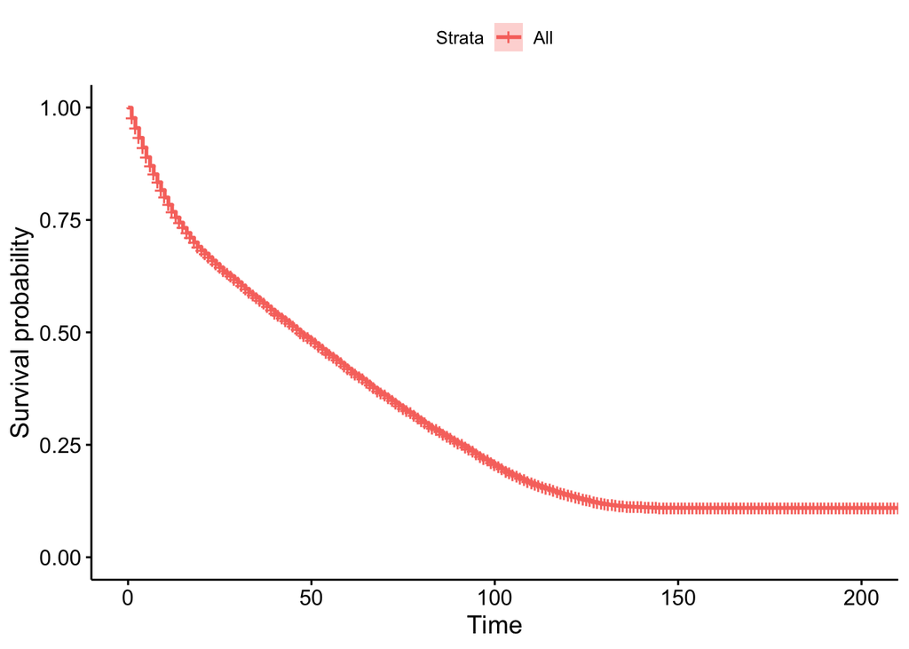

```r
covid<-read.csv("https://raw.githubusercontent.com/nazzstat/SurvivalData/master/Covid_Mexico.csv")

library(survival)
library(survminer)

# converting dates
covid$FECHA_INGRESO <- as.Date(covid$FECHA_INGRESO)
covid$FECHA_SINTOMAS <- as.Date(covid$FECHA_SINTOMAS)

# General survival curve
surv.covid_general <- survfit(Surv(Time, Released2)~1, data=covid)
ggsurvplot(surv.covid_general)
```

We can see from our general surivival curve that as time goes on, survival probability decreases. In this case, the event variable is being released from the hospital and deemed to be in recovery. There is a median survival of roughly 47 days.

## Sex

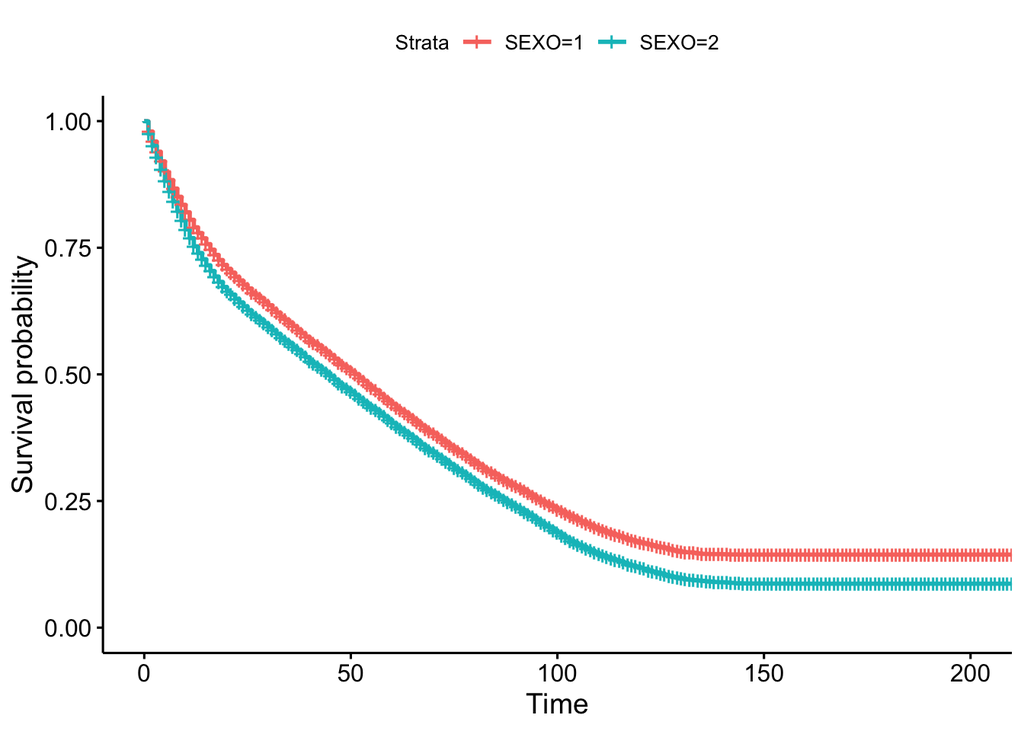

```r
sex.surv <- survfit(Surv(Time, Released2) ~ SEXO, data = covid)
ggsurvplot(sex.surv, conf.int = FALSE)
```

```r
survdiff(Surv(Time, Released2) ~ SEXO, data = covid, rho = 0)
```

```
## Call:
## survdiff(formula = Surv(Time, Released2) ~ SEXO, data = covid,
##     rho = 0)
##
##             N Observed Expected (O-E)^2/E (O-E)^2/V
## SEXO=1  74318    43085    46780       292       513
## SEXO=2 107718    68034    64339       212       513
##
##  Chisq= 513  on 1 degrees of freedom, p= <2e-16
```

```r
coxph(Surv(Time, Released2) ~ SEXO, data = covid)
```

```
## Call:
## coxph(formula = Surv(Time, Released2) ~ SEXO, data = covid)
##
##          coef exp(coef) se(coef)     z      p
## SEXO 0.139490  1.149688 0.006158 22.65 <2e-16
##
## Likelihood ratio test=518  on 1 df, p=< 2.2e-16
## n= 182036, number of events= 111119
```

Males have higher survival probability than females. This means that men stay in the hospital longer than women do. In other words, women are released and deemed in recovery sooner than men. There is a significant difference in the survival curves between the two sexes (X2(1) = 513, p-value < 0.001). We can see from the coxph model that there is a significant difference in hazards for sex (z = 22.65, p-value < 0.001). Females have a hazard of being released from the hospital that is 1.15 times higher than that of males.

## Age

```r
# Age of patient
# Make age groups
covid$age_group[covid$EDAD < 30 ] <- "less_than_30"
covid$age_group[covid$EDAD >= 30 ] <- "30_to_50"
covid$age_group[covid$EDAD > 50 ] <- "greater_than_50"

# assess number of patients in each age group
summary(covid$EDAD)
```

```
##    Min. 1st Qu.  Median    Mean 3rd Qu.    Max.
##    0.00   42.00   55.00   53.49   67.00  118.00
```

```r
summary(factor(covid$age_group))
```

```
##        30_to_50 greater_than_50    less_than_30
##           53526          109472           19038
```

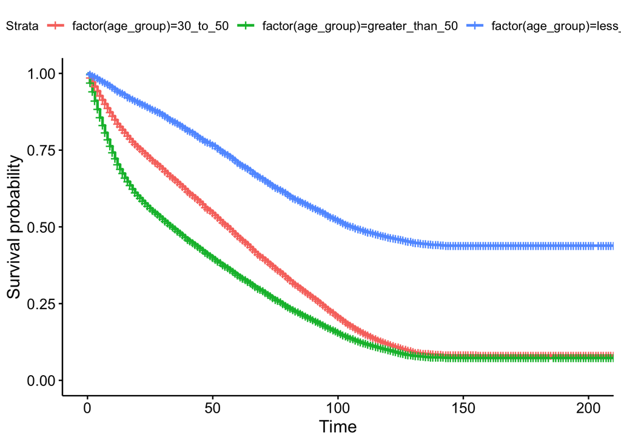

```r
surv.patient_age <- survfit(Surv(Time, Released2)~factor(age_group), data=covid)
ggsurvplot(surv.patient_age, conf.int = FALSE)
```

```r
# Estimated median survival time in days by age for when someone was admitted into hospital
covid$admission_date_stage[covid$FECHA_INGRESO < as.Date("2020-04-01") ] <- "stage1"
covid$admission_date_stage[covid$FECHA_INGRESO >= as.Date("2020-04-01") ] <- "stage2"
covid$admission_date_stage[covid$FECHA_INGRESO >= as.Date("2020-06-01") ] <- "stage3"

survdiff(Surv(Time, Released2) ~ age_group, data = covid, rho = 0)
```

```
## Call:
## survdiff(formula = Surv(Time, Released2) ~ age_group, data = covid,
##     rho = 0)
##
##                                N Observed Expected (O-E)^2/E (O-E)^2/V
## age_group=30_to_50         53526    33584    37424       394       606
## age_group=greater_than_50 109472    71525    57729      3297      7049
## age_group=less_than_30     19038     6010    15965      6208      7445
##
##  Chisq= 10202  on 2 degrees of freedom, p= <2e-16
```

Those who are younger than 30 have the highest survival probability. This means that they spend the most time in the hospital. Those who are older than 50 have the lowest survival probability, which means that they are released the soonest. There is a significant difference in the survival curves between the three age groups (X2(2) = 10202, p-value < 0.001).

## Date of Admission

```r
# split date of admission into stages
covid$admission_date_stage[covid$FECHA_INGRESO < as.Date("2020-04-01") ] <- "stage1"
covid$admission_date_stage[covid$FECHA_INGRESO >= as.Date("2020-04-01") ] <- "stage2"
covid$admission_date_stage[covid$FECHA_INGRESO >= as.Date("2020-06-01") ] <- "stage3"

# assess number of cases in each stage
summary(factor(covid$admission_date_stage))
```

```
## stage1 stage2 stage3
##   4228  62821 114987
```

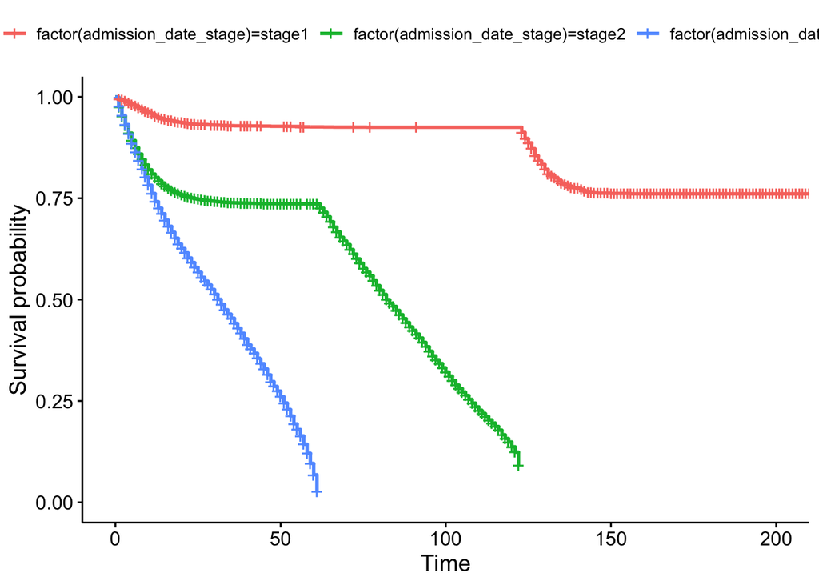

```r
# Survival curve for when a patient was admitted
surv.date <- survfit(Surv(Time, Released2)~factor(admission_date_stage), data=covid)
ggsurvplot(surv.date)
```

```r
surv.date
```

```
## Call: survfit(formula = Surv(Time, Released2) ~ factor(admission_date_stage),
##     data = covid)
##
##                                          n events median 0.95LCL 0.95UCL
## factor(admission_date_stage)=stage1   4228    732     NA      NA      NA
## factor(admission_date_stage)=stage2  62821  37614     82      82      83
## factor(admission_date_stage)=stage3 114987  72773     32      31      32
```

```r
survdiff(Surv(Time, Released2) ~ admission_date_stage, data = covid, rho = 0)
```

```
## Call:
## survdiff(formula = Surv(Time, Released2) ~ admission_date_stage,
##     data = covid, rho = 0)
##
##                                  N Observed Expected (O-E)^2/E (O-E)^2/V
## admission_date_stage=stage1   4228      732     7786      6391      8381
## admission_date_stage=stage2  62821    37614    58450      7428     19069
## admission_date_stage=stage3 114987    72773    44883     17331     39378
##
##  Chisq= 43650  on 2 degrees of freedom, p= <2e-16
```

```r
mod1<-survreg(Surv(Time, Released2)~as.factor(admission_date_stage)+EDAD, data=covid, dist="exponential")
summary(mod1)
```

```
##
## Call:
## survreg(formula = Surv(Time, Released2) ~ as.factor(admission_date_stage) +
##     EDAD, data = covid, dist = "exponential")
##                                           Value Std. Error     z      p
## (Intercept)                            7.221297   0.037850 190.8 <2e-16
## as.factor(admission_date_stage)stage2 -1.862734   0.037330 -49.9 <2e-16
## as.factor(admission_date_stage)stage3 -2.812763   0.037167 -75.7 <2e-16
## EDAD                                  -0.014395   0.000166 -86.7 <2e-16
##
## Scale fixed at 1
##
## Exponential distribution
## Loglik(model)= -549495   Loglik(intercept only)= -572269.4
##  Chisq= 45548.79 on 3 degrees of freedom, p= 0
## Number of Newton-Raphson Iterations: 5
## n= 182036
```

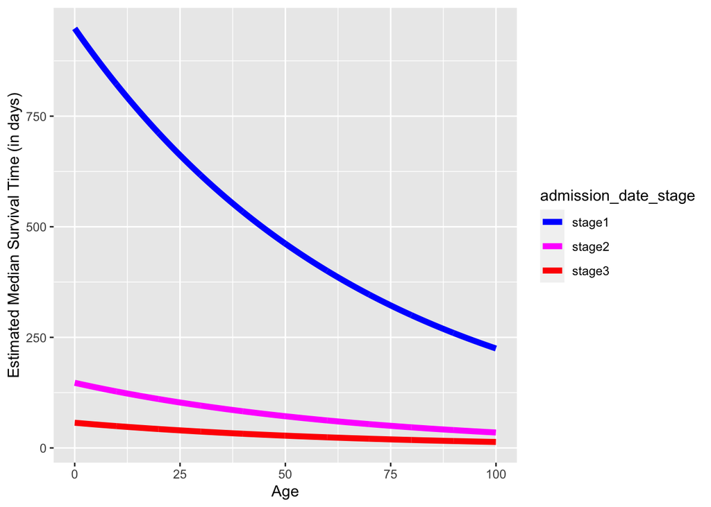

```r
library(ggplot2)
newdata <- expand.grid(admission_date_stage=c("stage1","stage2","stage3"), EDAD=seq(0,100,.1))
plotdata <- cbind(newdata, median=(predict(mod1,newdata=newdata,type="response"))*(-log(0.5)))

ggplot(data=plotdata)+
  geom_line(aes(x=EDAD, y=median, color=as.factor(admission_date_stage)), size=2)+
  scale_color_manual("admission_date_stage", values=c("blue","magenta", "red"))+
  ylab("Estimated Median Survival Time (in days)")+
  xlab("Age")
```

People who were admitted before April 1st, 2020 have the highest survival probability. This means that these people spend the longest amount of time in the hospital. People who were admitted after June 1st, 2020 have the lowest survival probability. This could potentially be a result of hospitals being more prepared to handle covid cases and help patients recover quicker, or that hospitals are more strained with patient numbers and have to release patients sooner to make room for others. There is a significant difference in the survival curves between the three admission stages (X2(2) = 43650, p-value < 0.001). After creating an estimated survival curve and analyzing the distribution of the admission_group_stage variable, we saw that there were not enough clear events in the stage1 group to calculate a median value. Therefore, in our estimated median survival curve we see that stage1 has an extreme curve, with very high values. We can, however, interpret stage2 and stage3. Both of these stages as you get older, the estimated median survival time decreases.